# Laporan PT Green Charge Indonesia

PT Green Charge Indonesia

Finesya Aura Nadifa

04 July 2026

📋 **Laporan ini dibuat secara otomatis** oleh Sistem Pelaporan PT Green Charge Indonesia.  
Periode: **May 2026** | Data diperbarui: 04 July 2026, 14:05

# Ringkasan Eksekutif

⚡

5.885

Total Energi Tersalurkan (kWh)

🔌

186

Total Sesi Pengisian

💰

Rp 14.7 Jt

Total Pendapatan

📊

0.7%

Rata-rata Utilisasi Stasiun

# Tingkat Pemanfaatan Stasiun Pengisian

## Utilisasi per Stasiun

Tabel 1. Tingkat Utilisasi Stasiun Pengisian — May 2026

| ID Stasiun | Nama Stasiun | Total Sesi | Total kWh | Utilisasi (%) |
| --- | --- | --- | --- | --- |
| ST005 | Green Charge Kemang | 20 | 674.6 | 1.4 |
| ST008 | Green Charge Puri Indah | 16 | 608.7 | 1.0 |
| ST002 | Green Charge Kuningan | 20 | 543.9 | 0.8 |
| ST003 | Green Charge Gatot Subroto | 22 | 556.6 | 0.7 |
| ST007 | Green Charge Kelapa Gading | 10 | 281.4 | 0.7 |
| ST009 | Green Charge Cibubur | 20 | 674.0 | 0.7 |
| ST001 | Green Charge Sudirman | 15 | 637.9 | 0.6 |
| ST004 | Green Charge TB Simatupang | 30 | 932.4 | 0.6 |
| ST006 | Green Charge Senayan | 21 | 715.4 | 0.6 |
| ST010 | Green Charge Bekasi | 12 | 260.0 | 0.5 |

## Visualisasi Utilisasi Stasiun

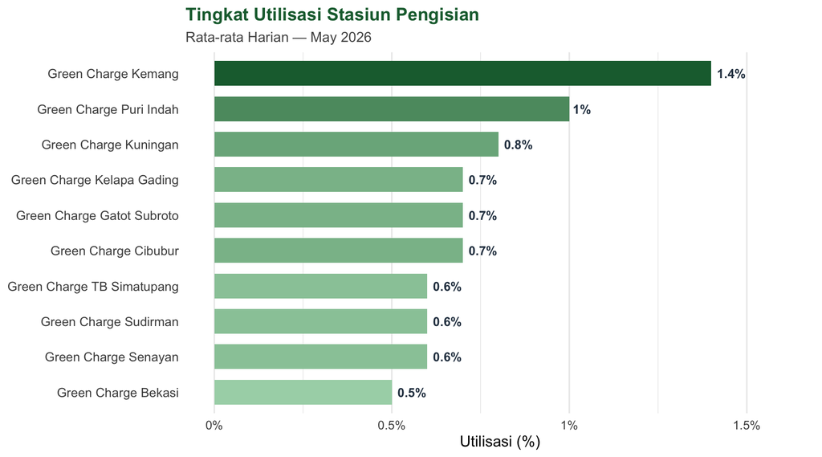

# Total Konsumsi Energi

## Tren Konsumsi Harian

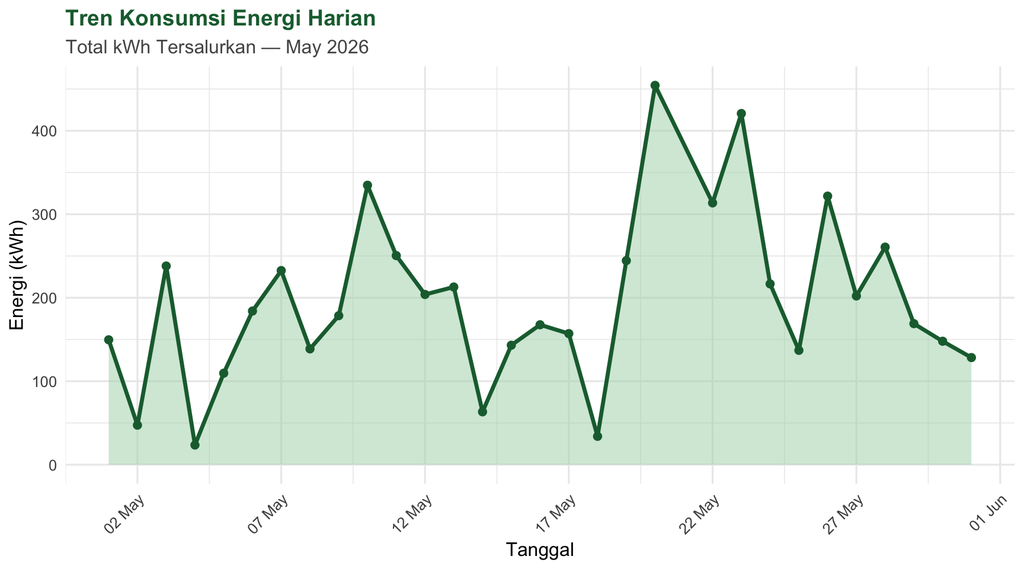

## Distribusi Konsumsi per Stasiun

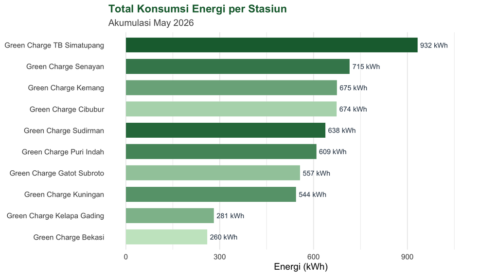

# Pendapatan

## Tren Pendapatan Harian

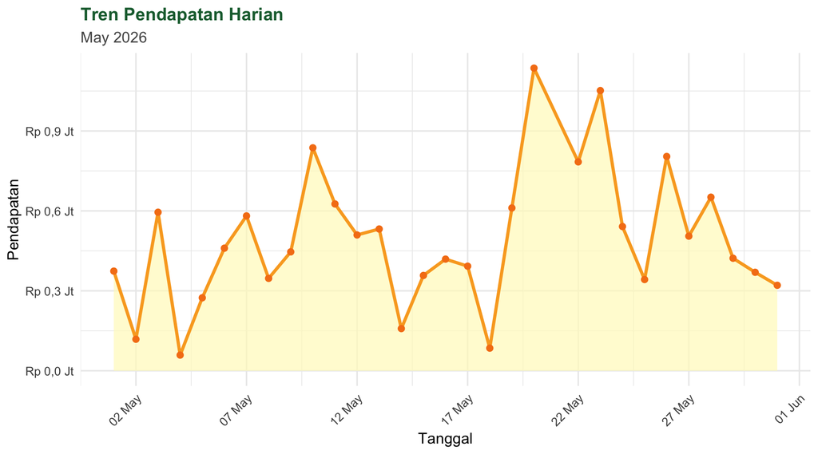

## Pendapatan per Stasiun

Tabel 2. Pendapatan per Stasiun — May 2026

| ID Stasiun | Nama Stasiun | Total kWh | Pendapatan |
| --- | --- | --- | --- |
| ST004 | Green Charge TB Simatupang | 932.4 | Rp 2.330.900 |
| ST006 | Green Charge Senayan | 715.4 | Rp 1.788.575 |
| ST005 | Green Charge Kemang | 674.6 | Rp 1.686.525 |
| ST009 | Green Charge Cibubur | 674.0 | Rp 1.684.900 |
| ST001 | Green Charge Sudirman | 637.9 | Rp 1.594.775 |
| ST008 | Green Charge Puri Indah | 608.7 | Rp 1.521.700 |
| ST003 | Green Charge Gatot Subroto | 556.6 | Rp 1.391.450 |
| ST002 | Green Charge Kuningan | 543.9 | Rp 1.359.750 |
| ST007 | Green Charge Kelapa Gading | 281.4 | Rp 703.425 |
| ST010 | Green Charge Bekasi | 260.0 | Rp 649.975 |

# Prediksi Permintaan Energi Bulan Berikutnya

## Data Historis 6 Bulan

| Bulan | Total Sesi | Total kWh | Pendapatan |
| --- | --- | --- | --- |
| January | 197 | 6054.37 | Rp 15.135.925 |
| February | 196 | 6309.20 | Rp 15.773.000 |
| March | 186 | 5790.35 | Rp 14.475.875 |
| April | 180 | 6100.65 | Rp 15.251.625 |
| May | 186 | 5884.79 | Rp 14.711.975 |
| June | 180 | 6035.34 | Rp 15.088.350 |

## Model Prediksi (Regresi Linear)

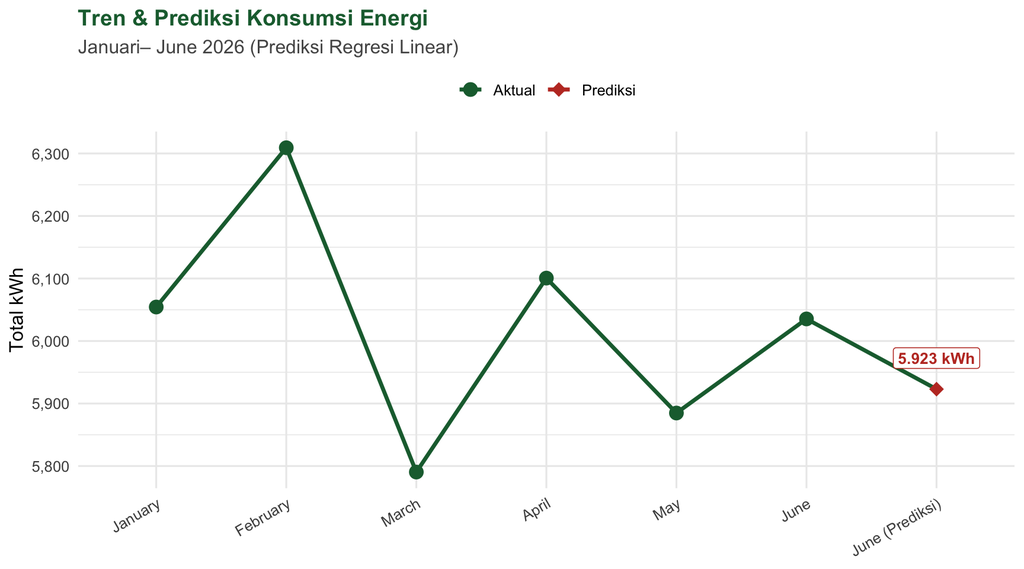

## Hasil Prediksi June 2026

Tabel 4. Perbandingan Aktual vs Prediksi — June 2026

[output not shown]

# Kesimpulan & Rekomendasi

**Ringkasan Kinerja Bulan May 2026:**

- Total energi tersalurkan mencapai **5.885 kWh** dari **186 sesi** pengisian yang berhasil.
- Total pendapatan bulan ini sebesar **Rp 14.711.975**.
- Stasiun dengan pendapatan tertinggi adalah **Green Charge TB Simatupang**.
- Rata-rata utilisasi stasiun sebesar **0.7%**.

**Rekomendasi untuk bulan June 2026:**

📌 *Laporan ini dibuat otomatis menggunakan R Markdown. Data bersumber dari sistem internal PT Green Charge Indonesia. Prediksi menggunakan model regresi linear berdasarkan data historis 6 bulan.*